# Festival Internacional del Globo, León Guanajuato

Black bird

03/12/2013

[figure not shown]

Todos los años en León sucede el Festival Internacional del Globo. Creo que incluso es la misma fecha del 15 al 18 de noviembre. Aprovechan el puente para hacer un gran evento al que yo, necio como yo solo, asistí con la pata esguinsada y muletas. La primera recomendación es, si tienen un esguince, ¡no vayan! no sean necios y esperen al año que viene.

Entonces, la cosa debería ser simple, durante tres días en las mañanas y en las noches hay eventos de globos, presentaciones, vuelos, etc. Durante el día hay una feria, presentaciones en vivo, etc. Cada noche hay un concierto diferente, easy cake, ¡pero no! Es un festival muy grande con muchas fallas de organización y hay que ir muy bien preparado porque tu viaje se puede frustrar muy fácilmente.

Antes que nada asegura tu hospedaje al menos dos semanas antes, el festival es muy famoso y va mucha gente por lo que se aperra, los hoteles más baratos (obviamente) son los primeros en acabarse por lo que en verdad les recomiendo que reserven lo antes posible. Otra cosa, la ciudad es un caos de tráfico así que busquen un hotel cerca del lugar del evento, que en este año fue en el Parque Metropolitando de León, al norte de la ciudad (no estoy seguro de que todos los años sea ahí). Para los “Warriors” existe la posibilidad de acampar en el propio parque, para eso les recomiendo que lleguen temprano porque también se aperra, creo que cuesta $150 la noche y además, si usan la entrada equivocada van a caminar un buen así que chequeen bien las entradas antes de estacionar el auto. El festival es en noviembre, así que durante la noche hace un frío del carajo, lleven harto sleeping, harta cobija y si pueden lo que viene siendo la “pompi”, el “amigo cariñoso”, la “pareja”, el “peor es nada”, “el novio la novia”, etc! Recuerden, el cuchareo es la mejor medicina contra el frío.

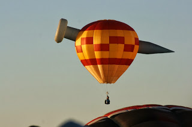

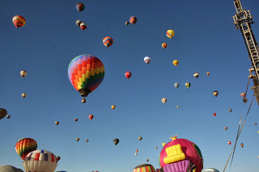

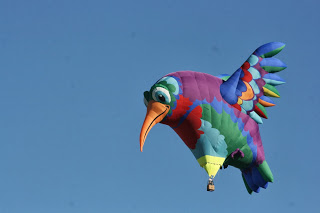

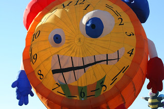

Entonces, suponiendo que ya están hospedados, el siguiente paso es sobrevivir a las masas de personas. Hordas de jóvenes corriendo de un lado para otro como antílopes en época de apareamiento, acercarse en carro es un suicido, mejor ve en taxi ah y olvida empedar adentro, casi no venden chupe tienes que pasarlo “con discreción” guiño-gioño. Con respecto a las entradas, yo me enteré que habían tres entradas:

La del Oxxo (léase “Ó-por-por-Ó”) sin duda la peor, es la más llena y la más lejana al sitio donde sucede el evento. Si llegas tarde demoras una hora en que el tren pase por ti, las bicicletas se acaban y la caminata es como de una hora, si vas a llegar por ahí, llega temprano, su ventaja es que hay un OxxO afuera.

La segunda y MEJOR entrada es en frente al lugar. Para esta entrada hay que rodear todo el parque e ir de carro, si te vas en Taxi está bueno porque el estacionamiento se aperra (además cobran $50). Esta entrada esta buena porque llegas directo a la feria y al escenario, para ver los globos, vale la pena un día ir a verlos al campo y la otra quedarse en el montículo de afuera, para tener una vista estilo panorámica.

La tercera entrada, es por el bulevar no sé qué chinga’os, de esa no sé nada pues no la usé pero creo que está más cerca que la entrada del Ó-por-por-Ó.

Una vez superados los primeros dos obstáculos (hospedaje y manadas) va información muy importante que nadie pudo decirme a pesar de lo fácil que es, los horarios:

1.- Los globos toman vuelo en la mañana, con que llegues a las 7am ves el primer globo salir y se salen todos entre 7 y 9-9.30am, La verdad podrías llegar a las 8am y aun así ves los globos salir y volar cerca. Aquí pueden ir con su carro el tráfico es inexistente y el estacionamiento a esa hora tiene lugar.

2.- En la noche hay conciertos, todas las noches toca alguien distinto, puntual a las 9pm y terminan puntual 11-12pm. No más, lo mejor es que llegues desde las 5 porque además dicen que se aperra el escenario.

3.- Así mismo, en la noche, a las 7pm hay una liberación de globos de cantona (¿así se llaman?) y un “chow de luces bien acá” En resumen, lleguen a las 7.30am, paguen estacionamiento vean los globos salgan como a las 11 vayan a comprar cuero y regresen en taxi a las 6pm para todo lo que sucede en la noche.

[figure not shown]

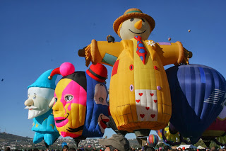

Para comer, hay un lugar que yo no fui pero mis amigos si, es un todo lo que pueda comer por x cantidad de pesos, creo que eran $180. Está en la entrada de León, del lado derecho y se llama, la Vaca o algo ganadero, estaba lleno entonces quiero creer que es muy bueno. También, y por favor no rían de mis indicaciones, hay un lugar para desayunar que está por la Toyota. Si vienen por la avenida grande donde está la Toyota, una calle antes de llegar a la agencia dan vuelta a la derecha, siguen por ahí y en la primera esquina hay un Oxxo al lado de este hay un lugar casual para desayunar maravilloso, espero lleguen, pidan chilaquiles verdes con huevo y carne ;). Uy uy! Además hay jugo de naranja natural, pero ni se molesten en pedir café, en verdad no Por último, el “fashion tip” León es muy conocida por su gran variedad de cueros (me refiero a ropa pervertidos) no solo cuero si no que además hacen muy buenos zapatos y resulta que ese mismo fin de semana es el famoso “gran fin” por lo que hay unas “verdaderas gangas” según esto, eso si, lleven toda la paciencia posible porque las tiendas se atascan y los estacionamientos son verdaderos caos. En la salida rumbo a Queretown están los Outlets del lado derecho y en el centro (creo) hay un mercado gigante de puros productos de cuero.

[figure not shown]